# Traffic patterns in the city center of Thessaloniki

## Preliminary Wrangling

The dataset used in this project, includes traffic data of 9 roads located in the city center of Thessaloniki from the years 2015 to 2020. These 9 particular roads, are located around the reference air-quality monitoring station which is the reason they are chosen.The data source is a project called TrafficThess for which you can find more information [here](https://www.trafficthess.imet.gr/). The data were accessed through the "historical data" option in this website. Originally the website provides one dataset for each road seperately, where the variables of interest are statistical parameters of the speeds of several taxis passing through the road and each observation differs by a 15 minute interval (or more) from the previous.The dataset provided here is an engineered version of all those datasets merged together. In detail, there were originally 9 datasets from which we used the variables mentioned below:

- timestamps : Time of the recording
- id : A number that is given by the TrafficThess project to each road
- road name : Name of the road in Greek characters
- average speed ($u$): The average speed of all the taxis within the time recording interval
- free flow speed ($u_f$): The speed at which a vehicle can move in the road at zero congestion conditions

In order to merge the 9 roads into 1 dataset we performed the following operations:

1. Upsampled the data for all the roads so that we have hourly observations
2. Estimated the traffic performance index (tpi) for each road, which scales from 0 (no traffic congestion) to 1 (full congestion) and is defined as $(u_f - u)/u_f$
3. Tagged each column with name of the road and the id in parentheses
4. "Downscaled" any tpi values that are greater than 1 to 1. In fact an outlier analysis was performed and it was determined that most outliers fall within the road's free flow speed limit, so removing outliers would be a loss of information. Also speed limits often get exceeded but that does not mean that those observations are errors.

Our goals through analyzing this dataset are:

1. To provide insights in the relationships between traffic conditions in different roads to answer as to how a single traffic congestion variable could be created to represent the whole area and serve as a variable to be compared with the air-pollution data provided by the station. For example, would averaging the 9 roads be a good choice? Or are there extreme differences between them.
2. to provide neat visualizations that communicate the traffic patterns in the city center of Thessaloniki. We can create extra categorical features that correspond to hour, day, and month to help capture and visualize patterns in the traffic data

```python
# import all packages and set plots to be embedded inline
import numpy as np
import pandas as pd
import matplotlib.pyplot as plt
import seaborn as sb
import warnings

warnings.filterwarnings('ignore')
%matplotlib inline

# setting plot styles
plt.style.use('seaborn-whitegrid')
plt.rcParams["figure.figsize"] = (20,10)
plt.rcParams["font.size"] = 22
```

> Let's load the data

```python
traff_df = pd.read_csv("traffic_thess_data.csv")
traff_df.head()
```

|  | Timestamps | Πλατεια Αγιας Σοφιας(1264) | Ερμου(2378) | Καρολου Ντηλ(2872) | Καρολου Ντηλ(3026) | Πλατεια Αγιας Σοφιας(695) | Ερμου(808) | Πλατεια Αγιας Σοφιας(890) | Πλατεια Αγιας Σοφιας(919) | Ερμου(975) |
| --- | --- | --- | --- | --- | --- | --- | --- | --- | --- | --- |
| 0 | 2015-03-20 01:00:00 | 0.383838 | 0.345000 | 0.575758 | 0.38 | 0.766667 | 0.465000 | 0.500000 | 0.585 | 0.420000 |
| 1 | 2015-03-20 02:00:00 | 0.343434 | 0.386667 | 0.545455 | 0.32 | 0.570000 | 0.406667 | 0.363636 | 0.570 | 0.406667 |
| 2 | 2015-03-20 03:00:00 | 0.196970 | 0.335000 | 0.575758 | 0.62 | NaN | 0.355000 | 0.272727 | 0.680 | 0.450000 |
| 3 | 2015-03-20 04:00:00 | 0.151515 | 0.470000 | 0.000000 | NaN | NaN | NaN | NaN | NaN | 0.260000 |
| 4 | 2015-03-20 05:00:00 | 0.454545 | 0.340000 | 0.575758 | 0.06 | NaN | 0.335000 | 0.151515 | 0.500 | 0.360000 |

```python
traff_df.info()
```

```
<class 'pandas.core.frame.DataFrame'>
RangeIndex: 45023 entries, 0 to 45022
Data columns (total 10 columns):
 #   Column                      Non-Null Count  Dtype
---  ------                      --------------  -----
 0   Timestamps                  45023 non-null  object
 1   Πλατεια Αγιας Σοφιας(1264)  31700 non-null  float64
 2   Ερμου(2378)                 39002 non-null  float64
 3   Καρολου Ντηλ(2872)          36813 non-null  float64
 4   Καρολου Ντηλ(3026)          40113 non-null  float64
 5   Πλατεια Αγιας Σοφιας(695)   32385 non-null  float64
 6   Ερμου(808)                  36539 non-null  float64
 7   Πλατεια Αγιας Σοφιας(890)   31669 non-null  float64
 8   Πλατεια Αγιας Σοφιας(919)   26777 non-null  float64
 9   Ερμου(975)                  34330 non-null  float64
dtypes: float64(9), object(1)
memory usage: 3.4+ MB
```

## Data wrangling

> The data are pretty tidy, except from the timestamps each column represents the tpi of a road, and each row has the hourly average value. Some cleaniness issues are noted:
> 1. Greek characters and capital letters should be removed from the column names
> 2. The timestamps should be of datetime object type and not string
> 3. There are lots of missing values, we should examine their distribution and see if we can apply any imputation methods. One good option when working with variables of similar type is to use k-nn imputation.

First let's create a copy of the dataframe:

```python
tr_df_clean = traff_df.copy()
```

### Cleaniness issue 1

**Define**  
Replace capital letters and greek characters in the column names. In fact, the tpi column names aren't even descriptive regarding the value being represented, so we'll just use some new, descriptive names and map them to the old ones through a dictionary so that they can be used in the visualizations later on.

**Code**

```python
tr_df_clean.rename(columns={"Timestamps": "timestamps"}, inplace=True)
tr_df_clean.set_index('timestamps', inplace=True) # temporaly set timestamps as index
old_cols = tr_df_clean.columns
tr_df_clean.columns = ["tpi_a", "tpi_b", "tpi_c", "tpi_d", "tpi_e", "tpi_f", "tpi_g", "tpi_h", "tpi_i"]
road_names = dict(zip(tr_df_clean.columns, old_cols))
tr_df_clean.reset_index(inplace=True) # set index back to original one
```

**Test**

```python
print(road_names)
tr_df_clean.head()
```

```
{'tpi_a': 'Πλατεια Αγιας Σοφιας(1264)', 'tpi_b': 'Ερμου(2378)', 'tpi_c': 'Καρολου Ντηλ(2872)', 'tpi_d': 'Καρολου Ντηλ(3026)', 'tpi_e': 'Πλατεια Αγιας Σοφιας(695)', 'tpi_f': 'Ερμου(808)', 'tpi_g': 'Πλατεια Αγιας Σοφιας(890)', 'tpi_h': 'Πλατεια Αγιας Σοφιας(919)', 'tpi_i': 'Ερμου(975)'}
```

|  | timestamps | tpi_a | tpi_b | tpi_c | tpi_d | tpi_e | tpi_f | tpi_g | tpi_h | tpi_i |
| --- | --- | --- | --- | --- | --- | --- | --- | --- | --- | --- |
| 0 | 2015-03-20 01:00:00 | 0.383838 | 0.345000 | 0.575758 | 0.38 | 0.766667 | 0.465000 | 0.500000 | 0.585 | 0.420000 |
| 1 | 2015-03-20 02:00:00 | 0.343434 | 0.386667 | 0.545455 | 0.32 | 0.570000 | 0.406667 | 0.363636 | 0.570 | 0.406667 |
| 2 | 2015-03-20 03:00:00 | 0.196970 | 0.335000 | 0.575758 | 0.62 | NaN | 0.355000 | 0.272727 | 0.680 | 0.450000 |
| 3 | 2015-03-20 04:00:00 | 0.151515 | 0.470000 | 0.000000 | NaN | NaN | NaN | NaN | NaN | 0.260000 |
| 4 | 2015-03-20 05:00:00 | 0.454545 | 0.340000 | 0.575758 | 0.06 | NaN | 0.335000 | 0.151515 | 0.500 | 0.360000 |

### Cleaniness issue 2

**Define**  
Change the data type of timestamps to datetime object  
**Code**

```python
tr_df_clean['timestamps'] = pd.to_datetime(tr_df_clean['timestamps'])
```

**Test**

```python
tr_df_clean.info()
```

```
<class 'pandas.core.frame.DataFrame'>
RangeIndex: 45023 entries, 0 to 45022
Data columns (total 10 columns):
 #   Column      Non-Null Count  Dtype
---  ------      --------------  -----
 0   timestamps  45023 non-null  datetime64[ns]
 1   tpi_a       31700 non-null  float64
 2   tpi_b       39002 non-null  float64
 3   tpi_c       36813 non-null  float64
 4   tpi_d       40113 non-null  float64
 5   tpi_e       32385 non-null  float64
 6   tpi_f       36539 non-null  float64
 7   tpi_g       31669 non-null  float64
 8   tpi_h       26777 non-null  float64
 9   tpi_i       34330 non-null  float64
dtypes: datetime64[ns](1), float64(9)
memory usage: 3.4 MB
```

### Adding extra features

> Since we are interested in exploring the traffic patterns in time, we can use the timestamps to extract several categorical variables that will help us produce interesting visualizations. Interesting insights could be provided by the variables below:
> - hour of the day
> - day of the week
> - month of the year

Let's add those in our dataset

```python
tr_df_clean['hour'] = tr_df_clean.timestamps.dt.hour
tr_df_clean['day'] = tr_df_clean.timestamps.dt.strftime("%A") # extract day name
tr_df_clean['month'] = tr_df_clean.timestamps.dt.strftime("%B") # extract month name
tr_df_clean.head()
```

|  | timestamps | tpi_a | tpi_b | tpi_c | tpi_d | tpi_e | tpi_f | tpi_g | tpi_h | tpi_i | hour | day | month |
| --- | --- | --- | --- | --- | --- | --- | --- | --- | --- | --- | --- | --- | --- |
| 0 | 2015-03-20 01:00:00 | 0.383838 | 0.345000 | 0.575758 | 0.38 | 0.766667 | 0.465000 | 0.500000 | 0.585 | 0.420000 | 1 | Friday | March |
| 1 | 2015-03-20 02:00:00 | 0.343434 | 0.386667 | 0.545455 | 0.32 | 0.570000 | 0.406667 | 0.363636 | 0.570 | 0.406667 | 2 | Friday | March |
| 2 | 2015-03-20 03:00:00 | 0.196970 | 0.335000 | 0.575758 | 0.62 | NaN | 0.355000 | 0.272727 | 0.680 | 0.450000 | 3 | Friday | March |
| 3 | 2015-03-20 04:00:00 | 0.151515 | 0.470000 | 0.000000 | NaN | NaN | NaN | NaN | NaN | 0.260000 | 4 | Friday | March |
| 4 | 2015-03-20 05:00:00 | 0.454545 | 0.340000 | 0.575758 | 0.06 | NaN | 0.335000 | 0.151515 | 0.500 | 0.360000 | 5 | Friday | March |

### Questions worth exploring

> 1. How are the missing values in tpi's distributed?
> 2. How do the distributions of the tpi's look?
> 3. What is the average behavior for the different hours, days and months?

## Univariate Exploration

> In this section, we investigate distributions of individual variables. The 3 categorical variables drawn from the timestamps have a very predicatble behavior, so let's begin by dropping them for now

```python
roads_df = tr_df_clean.iloc[:,0:10]
roads_df.set_index('timestamps', inplace=True)
roads_df.head()
```

| timestamps | tpi_a | tpi_b | tpi_c | tpi_d | tpi_e | tpi_f | tpi_g | tpi_h | tpi_i |
| --- | --- | --- | --- | --- | --- | --- | --- | --- | --- |
| 2015-03-20 01:00:00 | 0.383838 | 0.345000 | 0.575758 | 0.38 | 0.766667 | 0.465000 | 0.500000 | 0.585 | 0.420000 |
| 2015-03-20 02:00:00 | 0.343434 | 0.386667 | 0.545455 | 0.32 | 0.570000 | 0.406667 | 0.363636 | 0.570 | 0.406667 |
| 2015-03-20 03:00:00 | 0.196970 | 0.335000 | 0.575758 | 0.62 | NaN | 0.355000 | 0.272727 | 0.680 | 0.450000 |
| 2015-03-20 04:00:00 | 0.151515 | 0.470000 | 0.000000 | NaN | NaN | NaN | NaN | NaN | 0.260000 |
| 2015-03-20 05:00:00 | 0.454545 | 0.340000 | 0.575758 | 0.06 | NaN | 0.335000 | 0.151515 | 0.500 | 0.360000 |

### Missing values visualization

We can use a heatmap to display the missing values patterns in our dataset. This can help us determine how to handle them from now on. [Here](https://dev.to/tomoyukiaota/visualizing-the-patterns-of-missing-value-occurrence-with-python-46dj) is a good article with more information on how to visualize missing values.

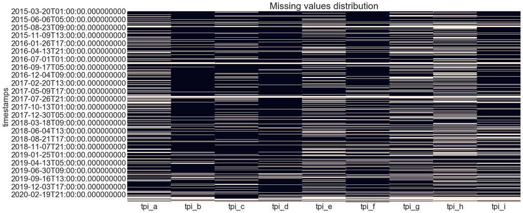

```python
sb.heatmap(roads_df.isnull(), cbar=False);
plt.title("Missing values distribution");
```

The missing values appear as white areas in our heatmap. We can draw two conclusions:

- **The missing value patterns are continuous (no large chunks with missing values appear)**
- **There isn't any single variable with too many missing values (e.g more than 50% or so)**

That means that a method like k-nn can be used to impute the missing values. Doing so in this large dataset would require a lot of computaitonal power so we won't do it, bu it could be applied on smaller sub-sets of this data if needed. In the visualizations we'll create later on, we'll group by averaging on the categorical variables we have created, so the missing values are not expected to create any problems

### Distribution visualization

We can also plot the distribution of each one of the tpi variables to see if they behave similarily

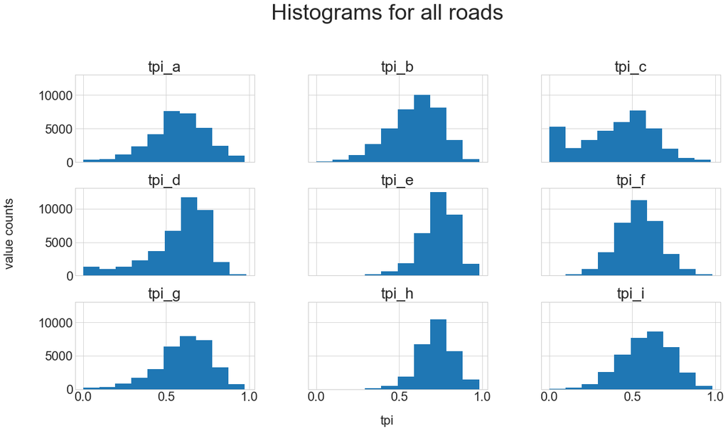

```python
fig, axes = plt.subplots(nrows=3, ncols=3, sharex=True, sharey=True)
roads_df.hist(ax=axes);
fig.suptitle("Histograms for all roads", x=0.5, y=1.05, ha='center', fontsize='xx-large');
fig.text(0.5, 0.04, 'tpi', ha='center');
fig.text(0.04, 0.5, 'value counts', va='center', rotation='vertical');
```

- **All the distributions show similar behavior, they appear to be skewed to the left with a mode between 0.5-0.8**
- **One of the distributions seems to be bimodal with a second mode indicating a tendency for free flow, this probably has to do with the way we choose to deal with outliers in these data in the preliminary wrangling. Instead of deleting them, we scale them down to the free flow speed because we have determined that speed limits are sometimes exceeded and these scenarios indicate low congestion, so we wouldn't like to drop this kind of information.**

## Bivariate Exploration

> In this section, we investigate relationships between pairs of variables in the data.

### Scatterplots between roads

Let's begin by examining relationships between nodes with some scatterplots. Since there are too many data points, we will only include the first month of the data so that the plots aren't overcrowded.

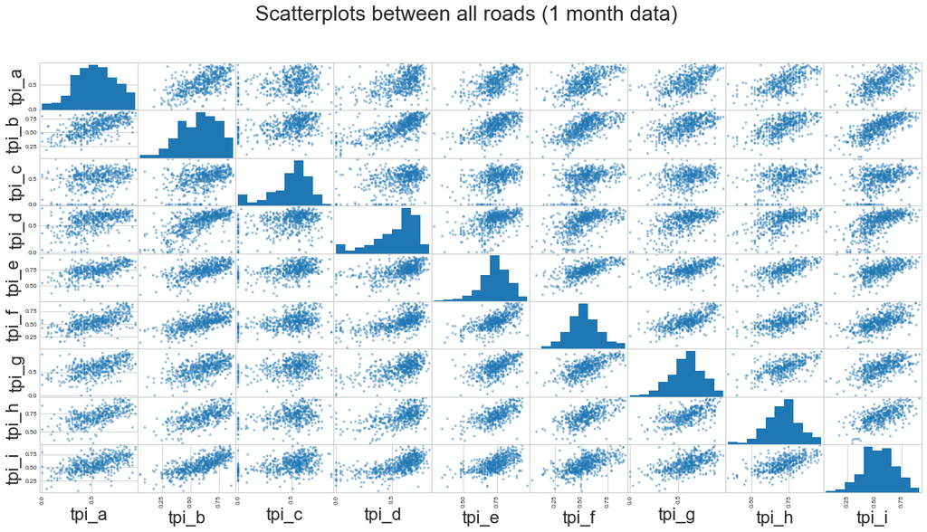

```python
pd.plotting.scatter_matrix(roads_df.iloc[0:24*7*4]); # data of one month
plt.suptitle("Scatterplots between all roads (1 month data)");
```

**The nodes appear to have a moderate correlation with each other**. Let's confirm this by calculationg the correlations as well

```python
roads_df.corr()
```

|  | tpi_a | tpi_b | tpi_c | tpi_d | tpi_e | tpi_f | tpi_g | tpi_h | tpi_i |
| --- | --- | --- | --- | --- | --- | --- | --- | --- | --- |
| tpi_a | 1.000000 | 0.408156 | 0.199223 | 0.345842 | 0.340992 | 0.367697 | 0.317681 | 0.356552 | 0.373803 |
| tpi_b | 0.408156 | 1.000000 | 0.239302 | 0.472729 | 0.392925 | 0.432020 | 0.352670 | 0.395831 | 0.492399 |
| tpi_c | 0.199223 | 0.239302 | 1.000000 | 0.232244 | 0.197800 | 0.217862 | 0.179722 | 0.201130 | 0.218450 |
| tpi_d | 0.345842 | 0.472729 | 0.232244 | 1.000000 | 0.348699 | 0.408596 | 0.335140 | 0.348192 | 0.406842 |
| tpi_e | 0.340992 | 0.392925 | 0.197800 | 0.348699 | 1.000000 | 0.419210 | 0.359548 | 0.390756 | 0.365753 |
| tpi_f | 0.367697 | 0.432020 | 0.217862 | 0.408596 | 0.419210 | 1.000000 | 0.417110 | 0.413257 | 0.415686 |
| tpi_g | 0.317681 | 0.352670 | 0.179722 | 0.335140 | 0.359548 | 0.417110 | 1.000000 | 0.346839 | 0.342038 |
| tpi_h | 0.356552 | 0.395831 | 0.201130 | 0.348192 | 0.390756 | 0.413257 | 0.346839 | 1.000000 | 0.378929 |
| tpi_i | 0.373803 | 0.492399 | 0.218450 | 0.406842 | 0.365753 | 0.415686 | 0.342038 | 0.378929 | 1.000000 |

### Average daily profiles of roads

Traffic data are expected to show repeating patterns every day. Studying the average daily profiles of each road can be meaningful to determine if those patterns are the same for different roads. If so this would be an indication of good quality in the data and it could mean that different roads can be combined to produce a single variable.

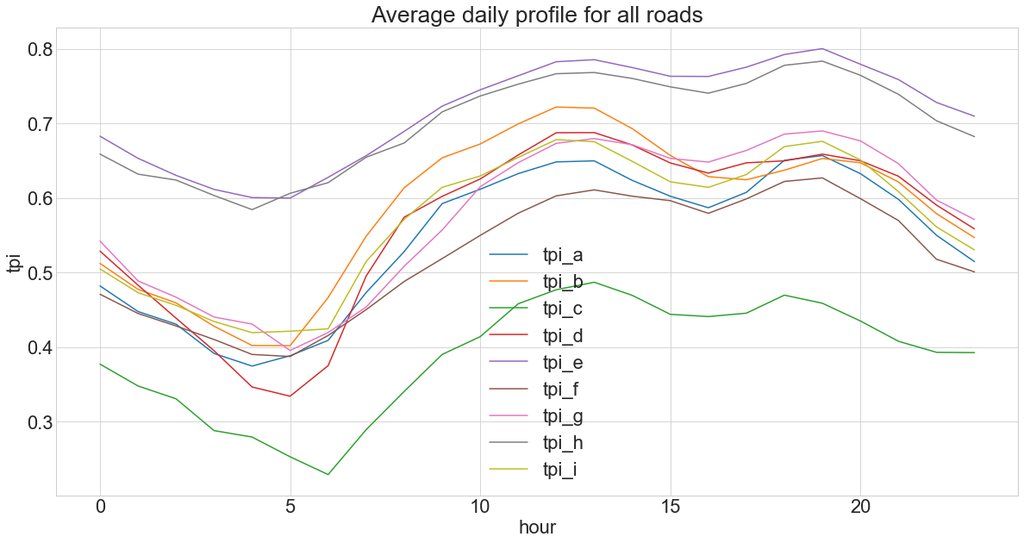

```python
hourly_df = tr_df_clean.groupby('hour').mean()
# daily_df.drop('hour', axis=1, inplace=True)
filled_markers = ('o', 'v', '^', '<', '>', '8', 's', 'p', '*') # by default it can't handle more than 5 markers
sb.lineplot(data=hourly_df, dashes=False, markers=False);
plt.title("Average daily profile for all roads");
plt.ylabel("tpi");
```

- **Even though the roads display different congestion levels their profiles show similar behavior during the day**
- **This typical behavior is minimum congestions at approximately 02:00 - 06:00 and maximum at 12:00 - 19:00 which usually tends to have a small decrease between 15:00 - 18:00**

Those last observations are enough to indicate that a single tpi variable can be engineered to describe the traffic congestion of the area in general. **The average of all the available traffic nodes would be a good approximation, or perhaps a research to determine if PCA analysis provides better results would be beneficial**. Those roads were manually picked so that they are approximately within a 100m radius of the air-pollution station. If automated access to all the traffic roads in the city is provided later on, a research on determining the ideal radius to pick and average data could be carried out by comparing the congestions estimated in different radii, with the air-pollution data. At the moment, we are just interested on visualizing traffic patterns based on the available data. Let's provide a new dataframe with the average tpi and the engineered categorical variables.

```python
avg_tpi = roads_df.mean(axis=1)
avg_tpi.rename('avg_tpi', inplace=True)
tr_df_clean.set_index('timestamps', inplace=True)
avg_tpi_df = pd.concat([avg_tpi, tr_df_clean.hour, tr_df_clean.day, tr_df_clean.month], axis=1)
avg_tpi_df.head()
```

| timestamps | avg_tpi | hour | day | month |
| --- | --- | --- | --- | --- |
| 2015-03-20 01:00:00 | 0.491251 | 1 | Friday | March |
| 2015-03-20 02:00:00 | 0.434725 | 2 | Friday | March |
| 2015-03-20 03:00:00 | 0.435682 | 3 | Friday | March |
| 2015-03-20 04:00:00 | 0.220379 | 4 | Friday | March |
| 2015-03-20 05:00:00 | 0.347102 | 5 | Friday | March |

### Day and month average barplots

Interesting insights could occur by studying the average concentration of our feature of interest (avg_tpi) by day and month. Barplots could provide a good visualization for this case.

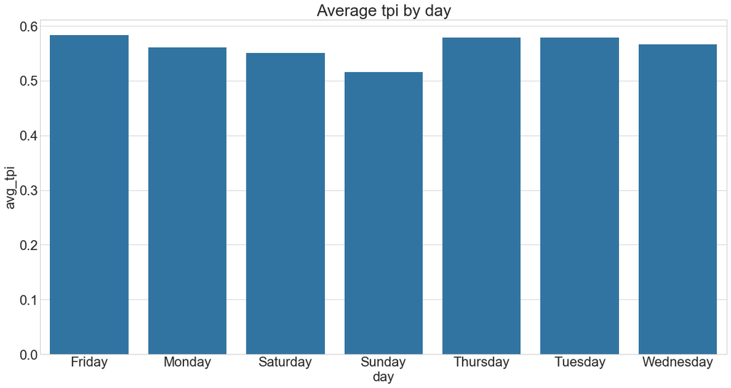

```python
daily_df = avg_tpi_df.groupby('day').mean().reset_index()
# daily_df.head()
first_color = plt.rcParams['axes.prop_cycle'].by_key()['color'][0] # get the first default color of matplotlib
sb.barplot(x="day", y="avg_tpi", data=daily_df, color=first_color);
plt.title("Average tpi by day");
```

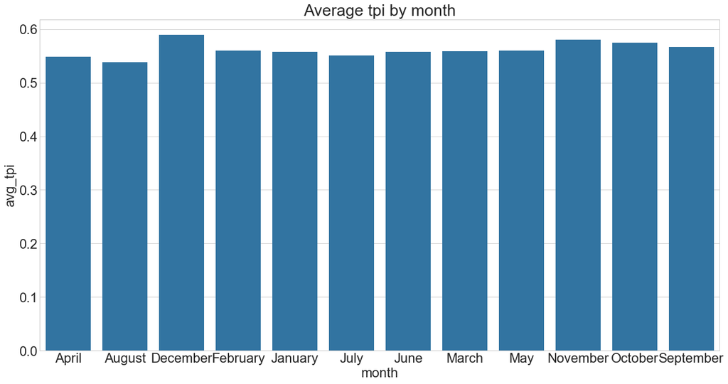

```python
monthly_df = avg_tpi_df.groupby('month').mean().reset_index()
# daily_df.head()
first_color = plt.rcParams['axes.prop_cycle'].by_key()['color'][0] # get the first default color of matplotlib
sb.barplot(x="month", y="avg_tpi", data=monthly_df, color=first_color);
plt.title("Average tpi by month");
```

## Multivariate Exploration

> We can create multivariate visualizations to see how smaller patterns in the tpi change during larger time periods. For example how would daily patterns change for different months. Heatmaps can be insightful in this case

### Daily tpi by month

We will create a heatmap to examine how the tpi scales for different days during different months

```
day          Friday    Monday  Saturday    Sunday  Thursday   Tuesday  \
month
April      0.569628  0.550794  0.536633  0.502941  0.560028  0.561533
August     0.555683  0.550377  0.514397  0.467778  0.552558  0.563785
December   0.609727  0.577225  0.591132  0.578416  0.595940  0.588952
February   0.584601  0.550191  0.555294  0.516658  0.574192  0.577104
January    0.572815  0.565783  0.556496  0.515713  0.573049  0.570836
July       0.570313  0.559104  0.517971  0.474753  0.579507  0.582020
June       0.576590  0.547640  0.539985  0.493275  0.582958  0.587208
March      0.583415  0.544437  0.551354  0.516429  0.573715  0.572399
May        0.583058  0.556933  0.546096  0.510003  0.581648  0.570981
November   0.599658  0.573802  0.579834  0.543660  0.592547  0.590569
October    0.595934  0.574428  0.571761  0.536503  0.587858  0.590581
September  0.585444  0.575172  0.541528  0.505417  0.595298  0.592046

day        Wednesday
month
April       0.555848
August      0.549920
December    0.581079
February    0.564290
January     0.550108
July        0.572006
June        0.575634
March       0.568302
May         0.566034
November    0.577058
October     0.567912
September   0.575397
```

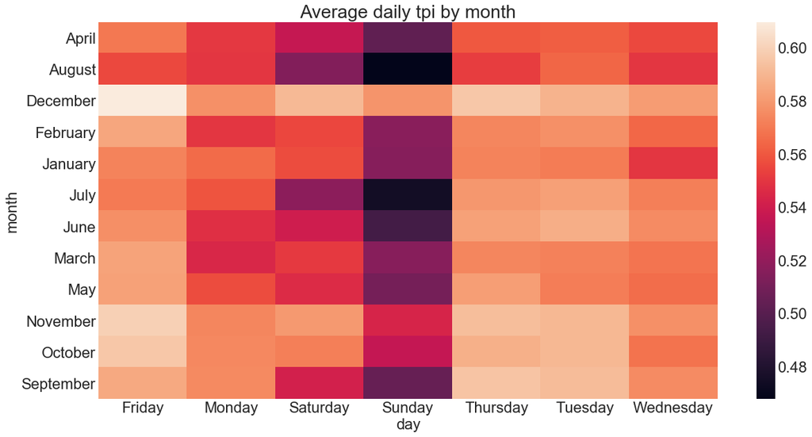

```python
multi_df1 = avg_tpi_df.groupby(['month', 'day']).mean().reset_index()
multi_df1.drop('hour', axis=1, inplace=True)
multi1 = multi_df1.pivot('month', 'day', 'avg_tpi') # scale to 2d table

print(multi1)
sb.heatmap(multi1);
plt.title("Average daily tpi by month");
```

- **Days and months that showed small congestions before, show the smallest congestions in total, when they occur at the same time (for example Sundays in summer months)**
- **Days and months that showed large congestions before, show the largest congestions in total, when they occur at the same time (for example fridays in December)**

### Hourly tpi by day

We will create a heatmap to examine how the tpi scales for different hours at different days

```
day     Friday    Monday  Saturday    Sunday  Thursday   Tuesday  Wednesday
hour
0     0.507583  0.486377  0.536606  0.564442  0.506899  0.492397   0.502520
1     0.466406  0.455957  0.498449  0.520426  0.473909  0.460886   0.472574
2     0.453218  0.441484  0.474435  0.482865  0.442165  0.457278   0.443510
3     0.433059  0.407268  0.438584  0.443808  0.403813  0.414135   0.417578
4     0.387679  0.385730  0.412946  0.410098  0.385969  0.393122   0.400031
5     0.380259  0.388356  0.375356  0.394892  0.363584  0.395239   0.381077
6     0.402226  0.416862  0.409617  0.393612  0.426870  0.431056   0.416963
7     0.513184  0.505229  0.444987  0.411052  0.508314  0.512236   0.506388
8     0.563140  0.558295  0.500791  0.446535  0.559208  0.569170   0.569122
9     0.616607  0.601978  0.541638  0.488414  0.613067  0.611552   0.605723
10    0.641324  0.622340  0.586594  0.520940  0.639034  0.636200   0.635594
11    0.671041  0.651639  0.614648  0.551126  0.664954  0.667504   0.661718
12    0.696302  0.667710  0.651612  0.582021  0.687164  0.682695   0.680669
13    0.699301  0.660053  0.673798  0.587159  0.681990  0.684568   0.670746
14    0.685936  0.647062  0.662248  0.566216  0.661212  0.659529   0.653894
15    0.664328  0.629286  0.631100  0.547093  0.641425  0.638608   0.641246
16    0.649570  0.622097  0.606462  0.552326  0.625478  0.623569   0.624665
17    0.650453  0.643727  0.590435  0.554689  0.661411  0.661353   0.630555
18    0.669624  0.665138  0.588367  0.567551  0.709278  0.699086   0.654086
19    0.680067  0.664044  0.589833  0.574182  0.728655  0.705115   0.648557
20    0.669036  0.638125  0.590035  0.575733  0.694074  0.677533   0.632096
21    0.654593  0.586766  0.592302  0.562372  0.648934  0.633880   0.597057
22    0.601735  0.542940  0.602776  0.539219  0.579023  0.568604   0.570236
23    0.581698  0.517022  0.588245  0.511500  0.543374  0.533947   0.528098
```

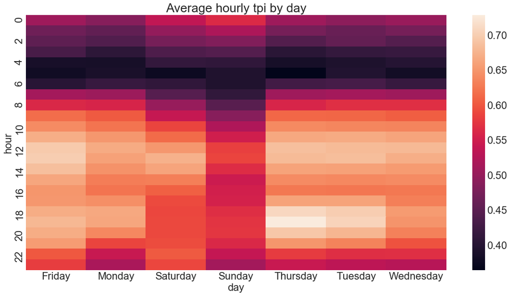

```python
multi_df2 = avg_tpi_df.groupby(['day', 'hour']).mean().reset_index()
multi2 = multi_df2.pivot('hour', 'day', 'avg_tpi')

print(multi2)
sb.heatmap(multi2);
plt.title("Average hourly tpi by day");
```

- **In general the findings agree with the ones in the average daily profiles for the single roads**
- **An interesting insight that was not clear before is that the maximum congestion occurs at Thursday and Tuesday afternoons.**

### Hourly tpi by month

We can also create a heatmap to visualize how the hourly congestions change by month

```
month     April    August  December  February   January      July      June  \
hour
0      0.480254  0.502837  0.535561  0.521031  0.522929  0.502911  0.506831
1      0.456845  0.466442  0.479432  0.487829  0.487962  0.479864  0.473780
2      0.453207  0.439509  0.458526  0.457907  0.467607  0.455632  0.449134
3      0.428714  0.408449  0.423705  0.418367  0.422017  0.422684  0.415900
4      0.391104  0.383713  0.394646  0.367695  0.396586  0.384891  0.408693
5      0.360602  0.391378  0.376648  0.360173  0.346764  0.391114  0.376635
6      0.409210  0.393400  0.418957  0.411839  0.392640  0.421470  0.430595
7      0.485364  0.466958  0.484944  0.493984  0.480652  0.470539  0.495084
8      0.512188  0.507913  0.545798  0.550354  0.530775  0.523057  0.544119
9      0.560417  0.552539  0.592599  0.583230  0.588384  0.568512  0.592721
10     0.594001  0.591124  0.625388  0.616830  0.607720  0.606146  0.620162
11     0.620430  0.614600  0.674040  0.646477  0.628916  0.640271  0.640575
12     0.645764  0.646301  0.703807  0.657695  0.659526  0.657459  0.658994
```

[output cut: 38 more lines]

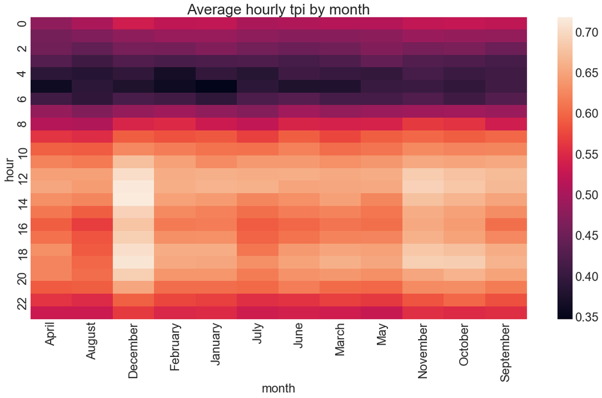

```python
multi_df3 = avg_tpi_df.groupby(['month', 'hour']).mean().reset_index()
multi3 = multi_df3.pivot('hour', 'month', 'avg_tpi')

print(multi3)
sb.heatmap(multi3);
plt.title("Average hourly tpi by month");
```